# The rmdmux package

A pagedown template  
by Adrian Maldet

Accessible reports  
with R  
A pagedown template

October 2022

## Imprint

Title

The rmdmux package - Write accessible reports in **R**

Edition

1st Edition

Date

October 2022

Place

Innsbruck

Publisher

Adrian Maldet  
My department

Author

Adrian Maldet (My company)  
John Doe (Doe univeristy)

Editor

Pippi Langstrumpf (Villa Kunterbunt)  
Pumukl (Kobold institute)

Address

Magnoliastreet 1  
6020 Innsbruck  
Austria

Phone

+99-999-9999

Email

my.email@fancy.at

Website

https://github.com/a-maldet/rmdmux

[figure not shown]

Credits

Hexsticker on cover page is © [2022 Adrian Maldet](https://github.com/a-maldet/rmdmux/tree/master/inst/hexsticker/rmdmux_hexsticker.png)  
R Logo on cover page is © [2016 The R Foundation](https://www.r-project.org/logo/)

The **rmdmux** package uses the pagedown R-Package by Yihui Xie et. al. Most of the code was taken from there and simply modified.

# My List Of Tables

- 2.1 Example-1 - A simple table
- 2.2 Example-2 - A table with custom theme
- 2.3 Example-3 - A more complex table

# My List Of Figures

- 2.1 Number of telephones in various regions of the world (in thousands)

# 1 Overview

The **rmdmux** package is an **R** package, which extends rmarkdown. It offers two additional output formats (html templates):

- `html_rmdmux_paged`: A beautiful **PDF** report
- `html_rmdmux_plain`: A plain **HTML** file, which fulfills the [WAI requirements](https://www.w3.org/WAI) and is therefore fully accessible by assistive reading devices like screen readers

With **rmdmux** you can create **a single RMD file** (see rmarkdown) and export it as PDF and as accessible HTML file.

> Documents should be beautiful and accessible!

The **rmdmux** package is a minor extension/variation of the wonderful **[pagedown](https://pagedown.rbind.io/)** package and therefore uses the **[pagedjs](https://pagedjs.org)** Javascript library in order to create paginated HTML files.

## 1.1 Install

Please install the following R packages from **github**:

- funky
- composerr
- [styledTables](https://github.com/R-package/styledtable) (v0.2.0 - deprecated)
- rmdmux

```r
devtools::install_github('a-maldet/funky', build_opts = NULL)
devtools::install_github('a-maldet/composerr', build_opts = NULL)
devtools::install_github('R-package/styledTables', ref = "v0.2.0", build_opts = NULL)
devtools::install_github('a-maldet/rmdmux', build_opts = NULL)
```

## 1.2 Getting started

In the following section we will have a look at the build-in example `ex1`. We can copy the entire example into our current working directory by executing the following code:

```r
library(rmdmux)
# copy `ex1/` to current working directory
create_example_1(".")
setwd("ex1")
```

The code above copies the following files into your working directory:

- `ex1_main.Rmd`: The main file containing the **yaml header** and linking the **distributed Rmd files** `ex1_child1.Rmd` and `ex1_child2.Rmd`
- `ex1_child1.Rmd` and `ex1_child2.Rmd`: Distributed chapters of the report
- `_bookdown.yml`: A **yaml** file configuring the used language translations for important report elements like **Figure**, **Table** etc. - see https://bookdown.org/yihui/bookdown/internationalization.html. If the report is rendered and the `_bookdown.yml` file is located in the same folder as the **Rmd** file, then the definitions in `_bookdown.yml` will automatically be included.
- `ex1_paged.sass`: An additional stylesheet, holding additional styling definitions for the reports paginated output format `html_rmdmux_paged`. This stylesheet is included in the **yaml header**.
- `ex1_plain.sass`: An additional stylesheet, holding additional styling definitions for the reports plain html output format `html_rmdmux_plain`. This stylesheet is included in the **yaml header**.
- `ex1_mytable.sass`: An additional stylesheet, which will be used in order to define a custom styling for table 2.2. This stylesheet is included in the chunk where the table is created.
- `ex1_cover.png`: An optional image, which will be placed in the center of the reports cover page. This image is included by setting the `title-page:image` option in the **yaml header**.
- `ex1_logo.png`: An optional image, which will be placed in the corner of the reports cover page. This image is included by setting the `title-page:logo` option in the **yaml header**.
- `ex1_qrcode.png`: An optional image, which contains a qr-code and is used as additional url visualisation on the imprint page (2nd page) of the report. This image is included by setting the `imprint:url-qrcode` option in the **yaml header**.

### 1.2.1 Rendering the report

As we can see in `ex1/ex1_run.R`, there are several ways to render the report:

- `rmarkdown::render("ex1_main.Rmd", output_format = "rmdmux::html_rmdmux_plain")`: Calling `rmarkdown::render()` is the usual way for rendering **Rmd** files. Be aware that while this will work fine for the plain html output (`html_rmdmux_plain`), it won’t for the paginated output (`html_rmdmux_paged`), since we will need a local **http** server, serving all required javascript files.
- `rmdmux::print_chrome("ex1_main.Rmd", output_format = "rmdmux::html_rmdmux_paged")`: This call prints the paginated report to a PDF file. Be aware that you need to have **Chrome** installed.
- `rmdmux::inf_mr("ex1_main.Rmd", output_format = "rmdmux::html_rmdmux_paged")`: This call is very useful, when you are working on report, since it will create a local **http** server, serving the rendered document as an **html document**. You just need to open the **url** (something like `127.0.0.1:4321/ex1_main.html`) printed in the console output in **Google Chrome** and you will see the current state of your report. If you change one of your **Rmd files** the report will automatically be rerendered and you just need to refresh your browser. In order to quit the **http** server, just call `rmdmux::daemon_stop()`

### 1.2.2 Supported features

- Almost all features of [pagedown](https://pagedown.rbind.io/) (except **running headers** and **front-cover** and **back-cover images**):
  - table of contents (see [bookdown/#table-of-contents](https://bookdown.org/yihui/rmarkdown/html-document.html#table-%20of-contents))
  - list of figures (see [pagedown/#LOT](https://pagedown.rbind.io/#LOT))
  - list of tables (see [pagedown/#LOT](https://pagedown.rbind.io/#LOT))
  - customized labels (language support) for report elements (see [pagedown/#internationalization](https://pagedown.rbind.io/#internationalization))
  - footnotes can be included in the page footer of the corresponding pages (see [pagedown/#footnotes](https://pagedown.rbind.io/#footnotes))
  - referencing figures, tables, sections etc. with counter and page number (see [pagedown/#page-references](https://pagedown.rbind.io/#page-references)) (Cation: The label for the page number references is defined in **css** and not in **_bookdown.yaml**)
  - additional styling for the plain and the paginated report version by using **sass** or **css** files (see [pagedown/#the-css-overriding-mechanism](https://pagedown.rbind.io/#the-css-overridin%20g-mechanism))
  - mathematical formulas in LaTeX (see [pagedown/#mathjax](https://pagedown.rbind.io/#mathjax))
  - automated creation of bibliography (see [pagedown/#bibliography](https://pagedown.rbind.io/#bibliography))
  - automated creation of a list of abbreviations (see [pagedown/#list-of-abbreviations](https://pagedown.rbind.io/#list-of-abbreviations))
- title page with
  - logo: optional small image in the upper right corner of the title page
  - image: optional big image in the center of the title page
  - footer: optional title page footer with left, center and right page footer area
- imprint page with:
  - report title field
  - edition field: Optional field holding the print edition
  - date field: Publishing date
  - place field: Optional field holding the place of pulication
  - publisher field: Optional field holding the name publisher name
  - author field: Field listing all authors
  - editor: Optional field listing all editors
  - address: Optional field holding the publisher address
  - phone number field: Optional field with phone number
  - email field: Optional field with email address
  - url field: Optional field with a publisher or report url
  - qr-code: Optional qr-code image
  - credits field: Optional credits for images etc.
  - remarks area: Optional remarks at the end of the imprint page
- fully accessible tables by using [styledTables](https://github.com/R-package/styledtable):
  - beautiful tables, which fulfill the [WAI requirements](https://www.w3.org/WAI) and are accessible by screen readers.
  - tables can optionally be included in the list of tables and be referenced by `\@ref(tab:CHUNKNAME)`
  - tables can have a table caption and table footer
  - tables can contain multiple header rows and multiple row header columns
  - tables can contain subheader rows splitting the table into muliple areas
  - tables can be suppressed/included depending on the rendered output format
  - the appearance of the tables can be modified by supplying custom **sass** or **css** files
- splitting up the **rmd** file into multiple files

### 1.2.3 Not supported features

The following features are supported by [pagedown](https://pagedown.rbind.io/)), but not by **rmdmux**:

- **front-cover** and **back-cover** (see [pagedown/#covers](https://pagedown.rbind.io/#covers)): This feature will most likely not be included anytime soon.
- **running headers** (see [pagedown/#custom-running-headers](https://pagedown.rbind.io/#custom-running-headers)): This feature will be included as soon as possible.

### 1.2.4 Create your own styles

Have a look at the following stylesheets:

- [rmdmux/inst/stylesheets/rmdmux_paged_default.sass](https://github.com/a-maldet/rmdmux/trees/master/inst/stylesheets/rmdmux_paged_default.sass) Default stylesheet for **paged html output**
- [rmdmux/inst/stylesheets/rmdmux_plain_default.sass](https://github.com/a-maldet/rmdmux/trees/master/inst/stylesheets/rmdmux_plain_default.sass): Default stylesheet for **plain html output**

You may want to modify them and include the new stylesheets in the `html_rmdmux_paged:css` and `html_rmdmux_plain:css` options of the reports **yaml** header.

# 2 Supported features by **rmdmux**

## 2.1 Distributed Rmd files

For longer reports it can be useful to distribute the code among multiple smaller **Rmd** files. In order to include an **Rmd** file (child file) in another **Rmd** file, one must include an empty chunk with setting the child files name in the chunk option `child="FILENAME_CHILD.Rmd"`.

## 2.2 Creating accessible tables

The **[styledTables](https://github.com/R-package/styledtable)** package allows the creation of accessible **html tables**. When creating the **plain html** using the `html_rmdmux_plain` output format, the resulting **html tables** will fulfill the **WAI** standards and therefore contain all required features in order to be fully accessible by screen reading devices, which are often used by visually impaired persons. Therefore, even very complex tables can be made accessible. Supported features:

- **complex column headers** with multiple header levels and merged cells
- **complex row headers** with multiple header levels and merged cells
- **multiple subheadings** partitioning the table into sub tables

### 2.2.1 Include styledTables in the **list of tables**

Unfortunately, **pagedown** currently only supports **Markdown** tables. This means that an **HTML table** will not be included in the generated **list of tables** (see the following [pagedown issue](https://github.com/rstudio/pagedown/issues/191)). In order to solve this problem, we must set the chunk option `tab.add_dummy_table = TRUE` at the beginning of each **Rmd** file containing one or more **styledTables**:

```r
knitr::opts_chunk$set(tab.add_dummy_table = TRUE)
```

This option ensures that the **styledTables** package automatically adds an empty **dummy table** before each printed **styledtable**. These dummy tables are only needed in order to include the **styledTables** in the **list of tables** page. The dummy tables will automatically be stripped when the document is knitted.

### 2.2.2 Create a simple styledTable

The following code prints a simple **styledTable**. The **table caption** and the **table footer** are defined in the chunk options. The **table reference** is defined by the **chunk name** (do not use underscores or white spaces in chunk names and be sure that all chunk names in the entire report are unique). The table can be refernced as follows `\\@ref(tab:usa-arrests)` resulting in the link 2.1 referencing the printed table. These references also work for distributed **Rmd** files.

A table usually consists of the following elements:

- A **table caption**, which holds a table reference and describes the contents of the table. The table caption is defined by the chunk option `tab.cap`.
- An optional **table footer**, which consists of one or several text blocks containing additional information about the table. The table footer can be defined by the chunk option `tab.footer`.
- **Column header rows**: These rows are usually at the top of the table and they hold the headings of the data columns. The function `set_html_colheader()` can be used in order to tell the styledTables package which rows are holding the column headings.
- **Row header columns**: These columns are usually at the left side of the table and they hold the headings of the data rows. The function `set_html_rowheader()` can be used in order to tell the styledTables package which rows are holding the column headings.
- **Sub headings**: These rows are usually single merged rows, which split the data table into multiple small sub tables and each sub table contains only the data valid for the context given by the corresponding sub heading. The function `set_html_subheading()` can be used in order to tell the styledTables package which rows are sub heading rows.

```r
library(dplyr)
library(styledTables)

df_usarrests <- USArrests %>%
  mutate(State = row.names(.)) %>%
  select(State, UrbanPop, Murder, Assault, Rape) %>%
  head

# create styledTable object
st_usarrests <- df_usarrests %>%
  styled_table(keep_header = TRUE) %>%
  set_html_colheader(row_id = 1) %>%
  set_html_rowheader(col_id = 1)

# apply default theme the the styledTable
st_usarrests %>%
  apply_html_theme1()
```

Table 2.1: Example-1 - A simple table

| State | UrbanPop | Murder | Assault | Rape |
| --- | --- | --- | --- | --- |
| Alabama | 58 | 13.2 | 236 | 21.2 |
| Alaska | 48 | 10 | 263 | 44.5 |
| Arizona | 80 | 8.1 | 294 | 31 |
| Arkansas | 50 | 8.8 | 190 | 19.5 |
| California | 91 | 9 | 276 | 40.6 |
| Colorado | 78 | 7.9 | 204 | 38.7 |

This is the table footer.  
The footer may contain multiple rows.

The function `apply_html_theme1()` applies the table styling defined in the stylesheet in [styledTables/inst/sass_files/styledtable_theme1.sass](https://github.com/R-package/styledtable/trees/master/inst/sass_files/styledtable_theme1.sass).

### 2.2.3 Apply your own table theme

In order to use your own table styling, you may want to have a look at the default stylesheet [styledTables/inst/sass_files/styledtable_theme1.sass](https://github.com/R-package/styledtable/trees/master/inst/sass_files/styledtable_theme1.sass) and create your own theme from it.

In the following example we

- create a stylesheet `ex1_mytable.sass` defining the css styling for tables of html class `mytable`
- transpile the stylesheet to `ex1_mytable.min.css`
- add the created **css** file to the **html dependencies** of the styled table object.
- add the **html class** `ex1-mytable` to the styled table object.

```r
# transpile to css
sass::sass(
  sass::sass_file("./ex1_mytable.sass"),
  output = "ex1_mytable.min.css",
  options = sass::sass_options(output_style = "compressed"),
  cache = FALSE
) %>% invisible

# add html dependency
st_usarrests_custom <- st_usarrests %>%
  add_html_stylesheet("ex1_mytable.min.css")

# add the html class "my-styledtable" and print the table
st_usarrests_custom %>%
  set_html_table_class("ex1-mytable")
```

Table 2.2: Example-2 - A table with custom theme

| State | UrbanPop | Murder | Assault | Rape |
| --- | --- | --- | --- | --- |
| Alabama | 58 | 13.2 | 236 | 21.2 |
| Alaska | 48 | 10 | 263 | 44.5 |
| Arizona | 80 | 8.1 | 294 | 31 |
| Arkansas | 50 | 8.8 | 190 | 19.5 |
| California | 91 | 9 | 276 | 40.6 |
| Colorado | 78 | 7.9 | 204 | 38.7 |

### 2.2.4 Create a complex styledTable

```r
library(tidyr)

df_haireye <- data.frame(HairEyeColor) %>%
  pivot_wider(names_from = c("Sex", "Eye"), values_from = "Freq")

st_haireye_body <- df_haireye %>%
  styled_table

# Create the styled table header
st_haireye_header <- c(
  "Hair", rep(c("Male", "Female"), each = 4),
  "", rep(c("Brown", "Blue", "Hazel", "Green"), times = 2)
) %>%
  styled_table(nrow = 2) %>%
  merge_cells(col_id = 1, row_id = 1:2) %>%
  merge_cells(col_id = 2:5, row_id = 1) %>%
  merge_cells(col_id = 6:9, row_id = 1)

# concatenate the styled table header and body,
# define col-/row-headers,
# apply `theme1` from `styledTables` package and then print the table
styled_table(
  st_haireye_header,
  st_haireye_body
) %>%
  set_html_colheader(row_id = 1:2) %>%
  set_html_rowheader(col_id = 1) %>%
  apply_html_theme1()
```

Table 2.3: Example-3 - A more complex table

| Hair | Male |  |  |  | Female |  |  |  |
| --- | --- | --- | --- | --- | --- | --- | --- | --- |
|  | Brown | Blue | Hazel | Green | Brown | Blue | Hazel | Green |
| Black | 32 | 11 | 10 | 3 | 36 | 9 | 5 | 2 |
| Brown | 53 | 50 | 25 | 15 | 66 | 34 | 29 | 14 |
| Red | 10 | 10 | 7 | 7 | 16 | 7 | 7 | 7 |
| Blond | 3 | 30 | 5 | 8 | 4 | 64 | 5 | 8 |

### 2.2.5 Conditional tables for plots

Plots are a great way to visualize data, but are not accessible to visually impaired people. Therefore, it is necessary to include a text or an accessible table describing the displayed data. With **styledTables** it is possible to append tables to figures only for the **plain html output**. This can be achieved by using the chunk option `tab.print = rmdmux::rmdmux_is_plain()`, which suppresses the printing of the additional styled table, if the current output format is not `html_rmdmux_plain`.

Figure 2.1: Number of telephones in various regions of the world (in thousands)

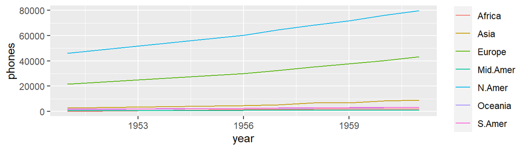

```r
library(ggplot2)

df <- data.frame(WorldPhones) %>%
  (tibble::rownames_to_column)("year") %>%
  mutate(year = as.numeric(year))
df %>%
  pivot_longer(cols = 2:8, names_to = "region", values_to = "phones") %>%
  {
    ggplot(.) +
      geom_line(aes(x = year, y = phones, color = region))
  }

styled_table(df, keep_header = TRUE) %>%
  styled_table %>%
  set_html_colheader(row_id = 1) %>%
  set_html_rowheader(col_id = 1) %>%
  apply_html_theme1()
```

In the `plain` export this plot is extended by an additional table holding the data. Note that, the chunk argument `fig.footer` is introduced in `rmdmux` for adding additional footer texts to figures.